Lake Name: Lake of the Woods

Lake acreage: 168.4

County: JEFFERSON

PWLID: 0906-0038

Waterbody Classification: C

Coordinates: 44.315399,-75.727798

Is this waterbody a public water supply: No

Are there DOH desingated beaches on this waterbody: No

Open Water Indicators

2018 Sampling Results

Seasonal Change

05-30

06-12

06-26

07-11

07-24

08-08

08-21

09-05

Clarity (m)

7.25

6.65

7.65

8.03

5.30

7.15

6.10

6.60

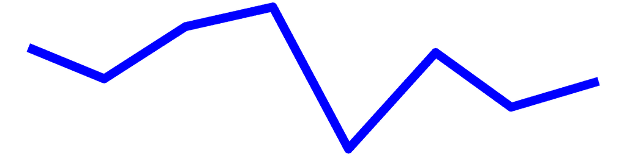

Surface TP (mg/L)

0.00

0.01

0.00

0.00

0.00

0.01

0.00

0.01

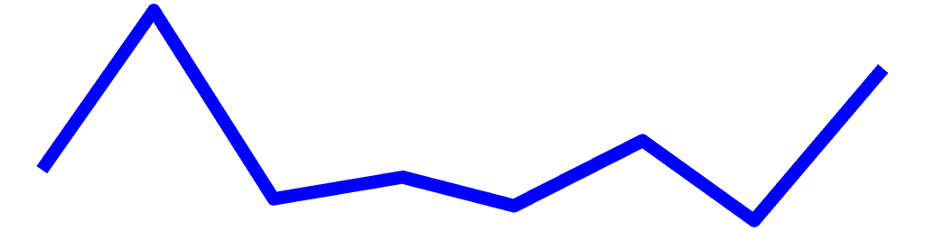

Surface TDP (mg/L)

0.00

0.00

0.00

0.01

0.00

0.01

0.00

0.00

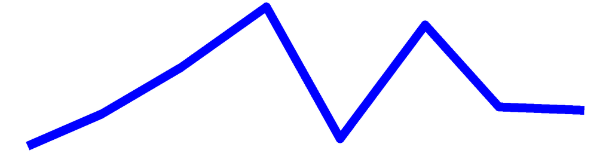

Deep TP (mg/L)

0.02

0.02

0.01

0.03

0.02

0.01

0.09

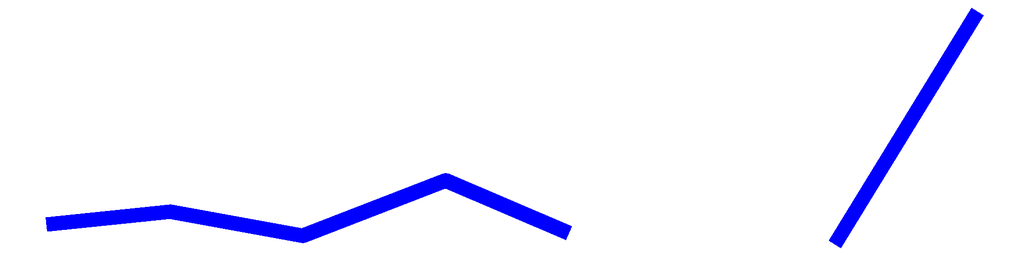

Deep TDP (mg/L)

0.00

0.00

0.01

0.02

0.00

0.01

0.03

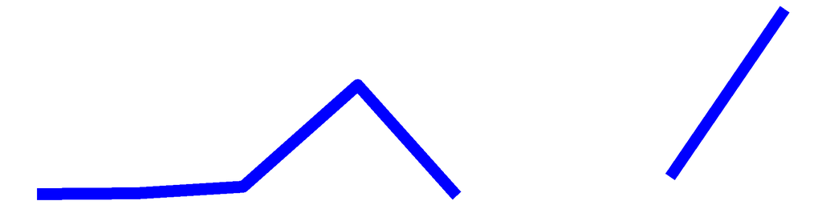

TN (mg/L)

0.58

0.35

0.20

0.33

0.27

0.36

0.28

0.36

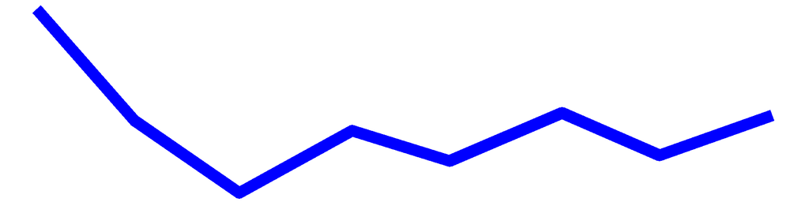

TDN (mg/L)

0.61

0.37

0.20

0.34

0.31

0.35

0.29

0.39

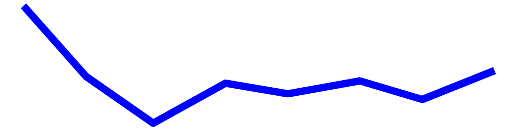

TN:TP

120.21

49.81

45.53

69.72

61.86

70.06

67.64

57.90

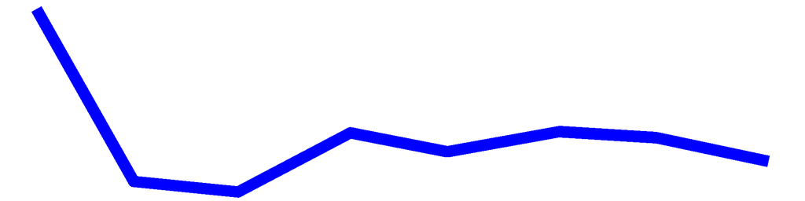

Surface NH3 (mg/L)

0.03

0.01

0.02

0.02

0.01

0.01

0.00

0.01

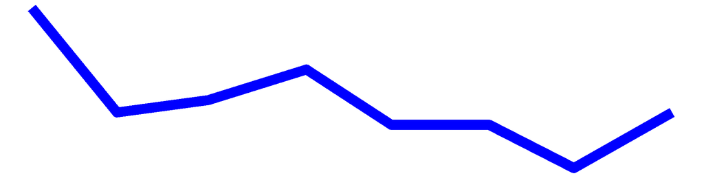

Deep NH3 (mg/L)

0.05

0.14

0.05

0.08

0.02

0.02

0.23

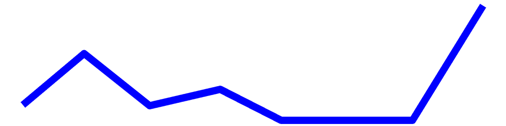

Chl.a (ug/L)

0.10

0.70

0.30

1.00

1.30

0.30

0.50

1.50

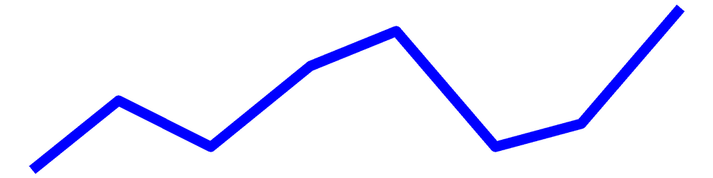

pH

7.55

7.80

7.75

7.91

7.54

6.84

6.67

7.55

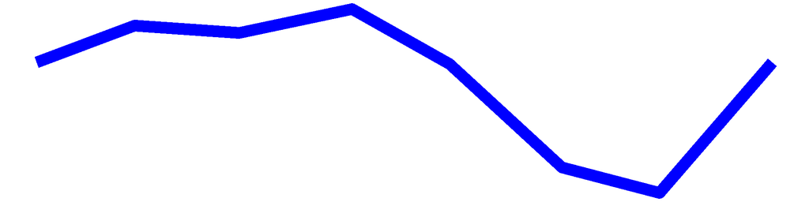

Cond (umho/cm)

105.50

93.60

92.00

88.90

86.60

90.20

85.10

90.60

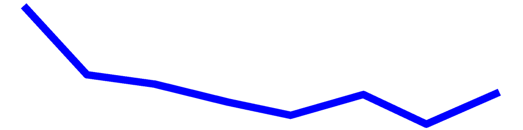

Surface Calcium (mg/L)

Bottom Calcium (mg/L)

Surface Chloride (mg/L)

11.00

5.00

Bottom Chloride (mg/L)

Upper Temp (degC)

19.00

22.00

24.00

26.00

27.00

27.00

24.00

28.00

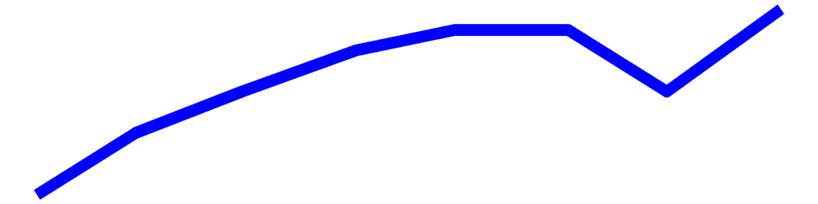

Deep Temp (degC)

7.00

10.00

8.00

9.00

11.00

10.00

9.00

10.00

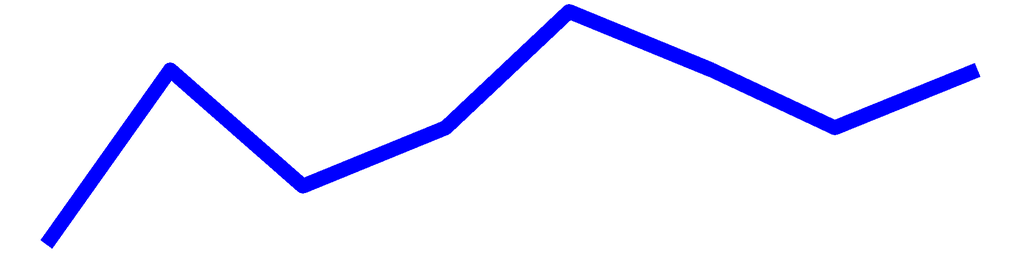

FP BG Chl.a (ug/L)

0.76

0.89

0.44

1.10

0.87

1.10

1.69

1.30

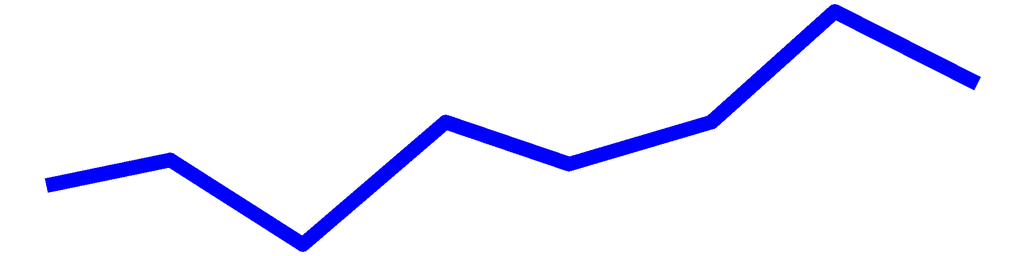

## Lake of the Woods – Sampling Season Results

### HABs Status

#### Open Water Algae

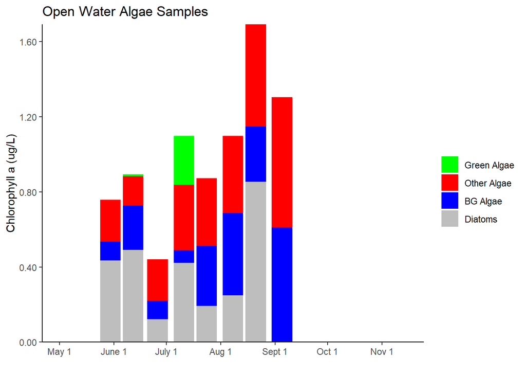

## Lake of the Woods Long-Term Trend Analysis

#### Clarity

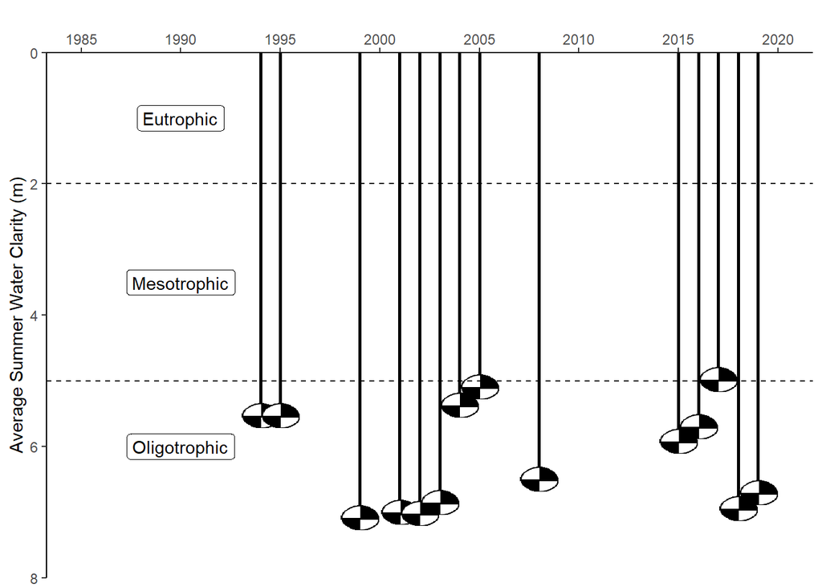

#### Chlorophyll *a*

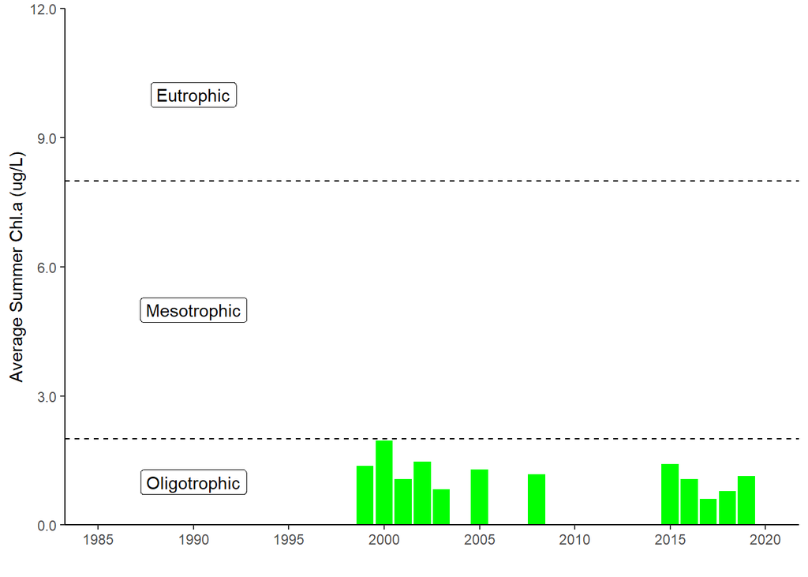

#### Surface and Deep Phosphorus

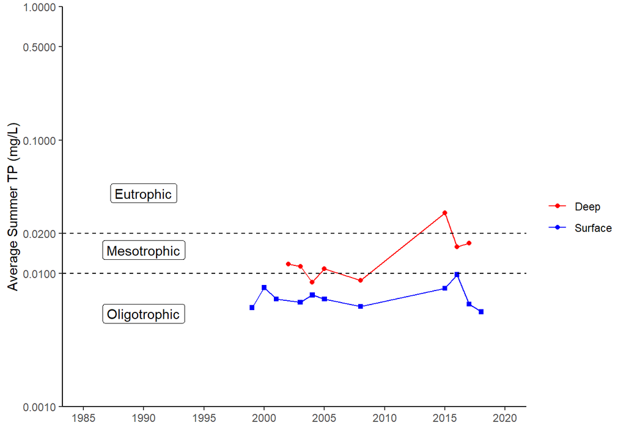

#### Nitrogen

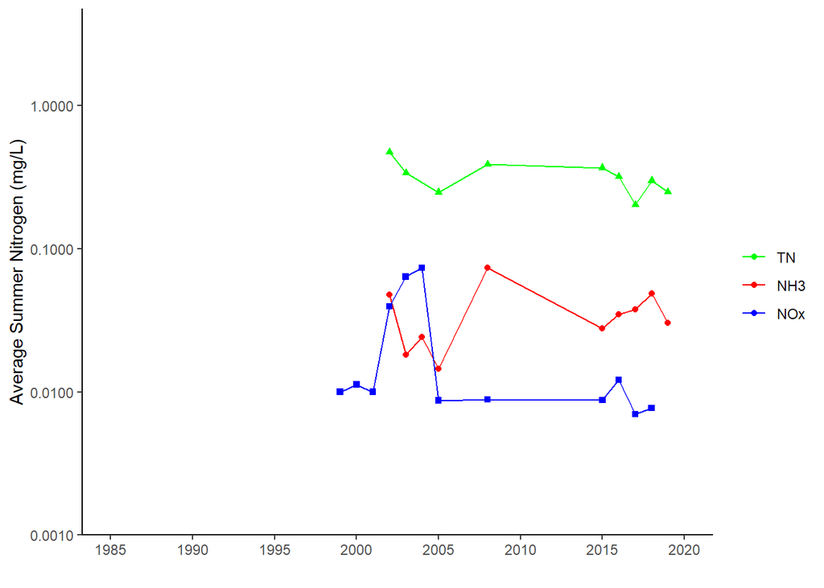

#### TN : TP

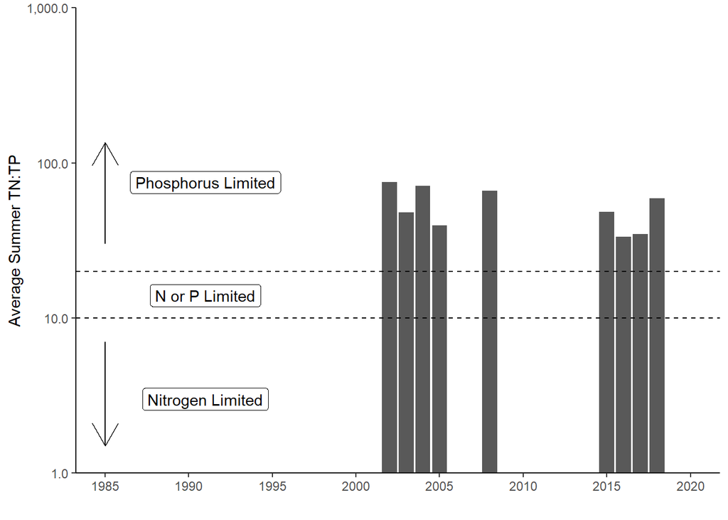

#### pH

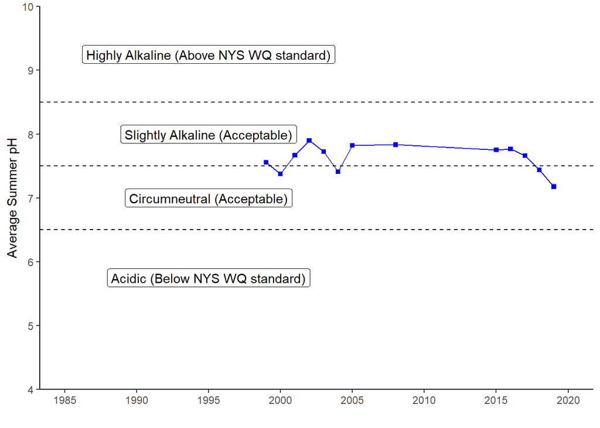

#### Specific Conductance

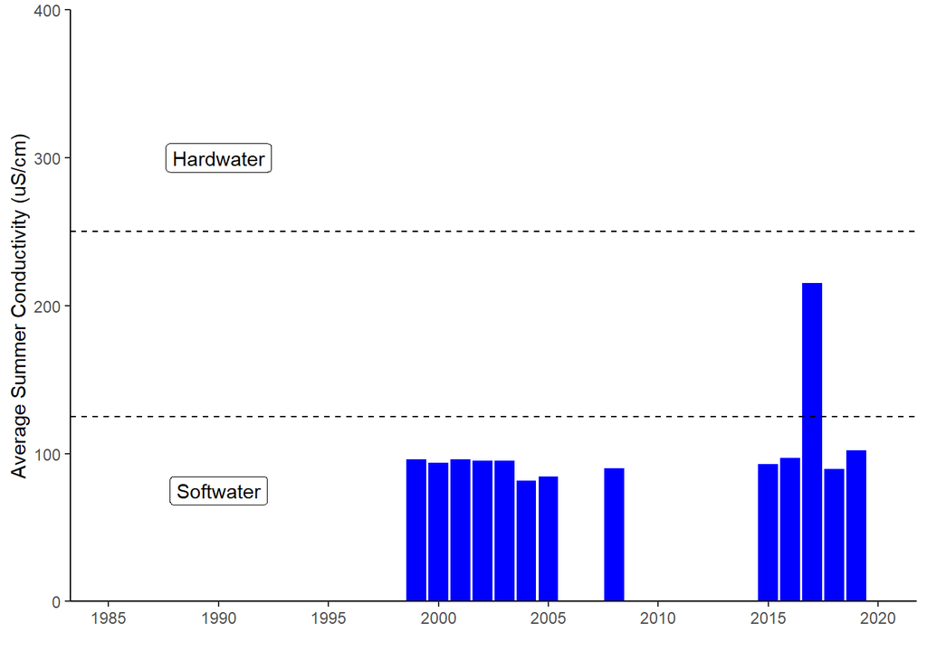

#### Calcium

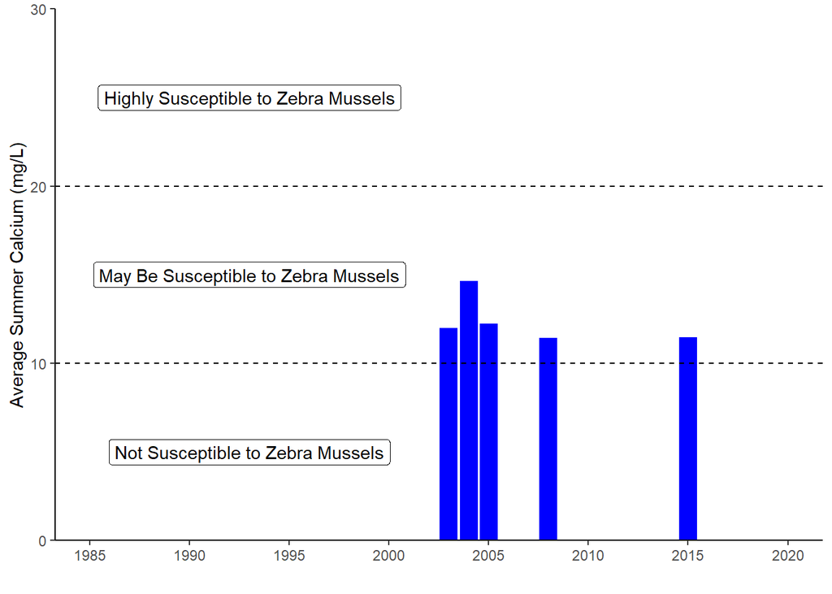

#### Chloride

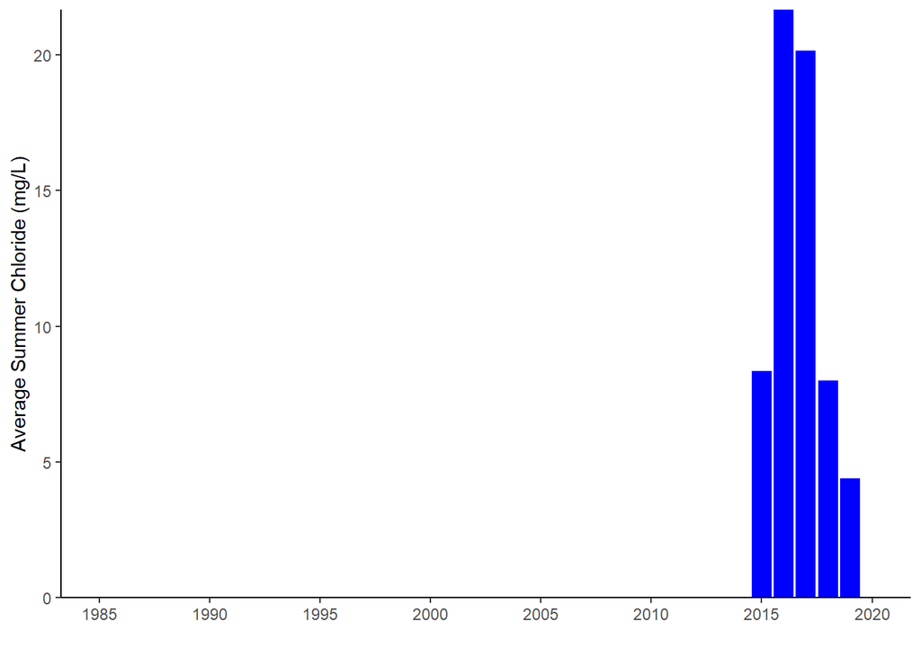

#### Color

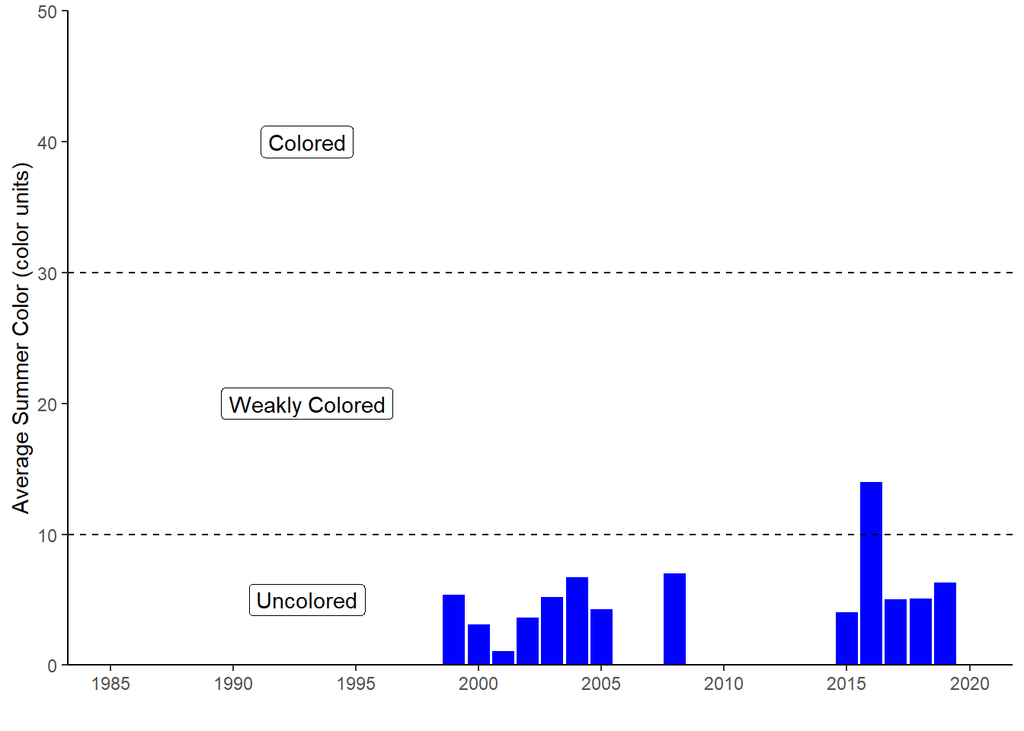

#### Surface and Deep Temperature

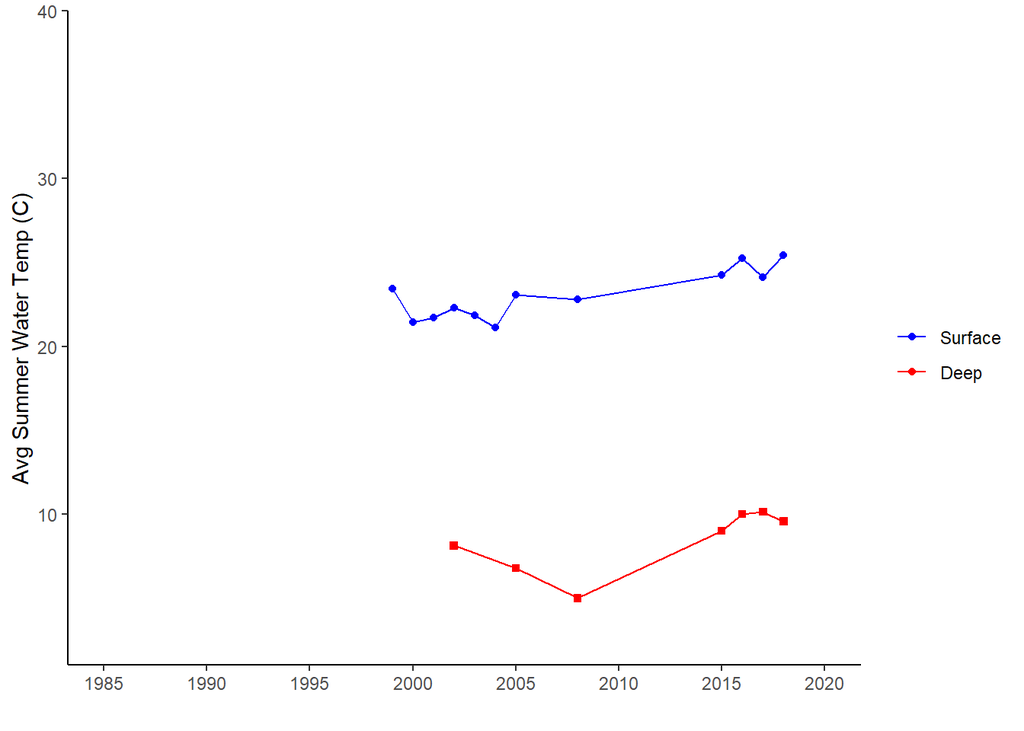

#### Lake Perception

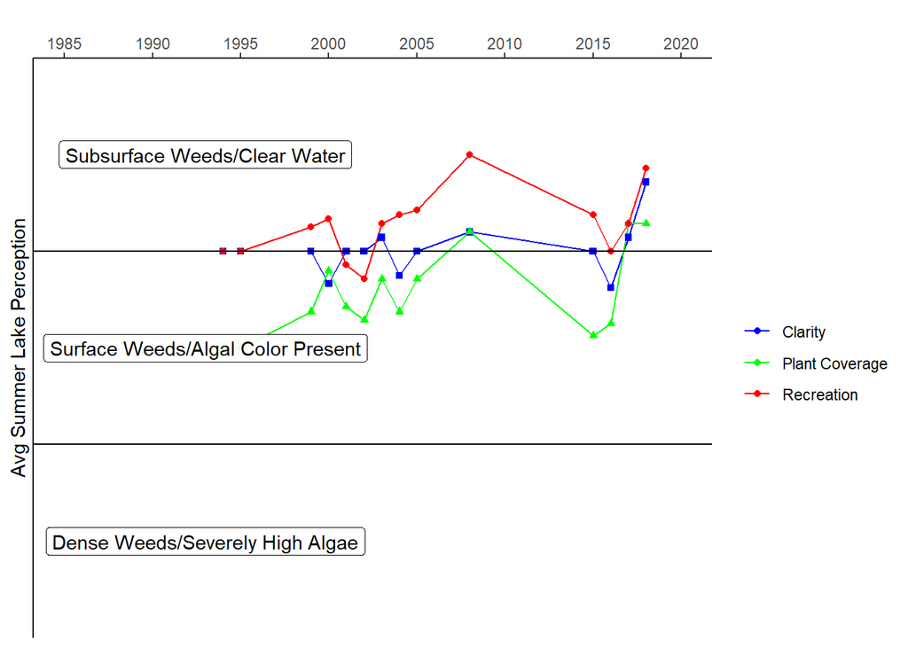

## Lake of the Woods - In-Season Analysis

#### In Season Water Clarity

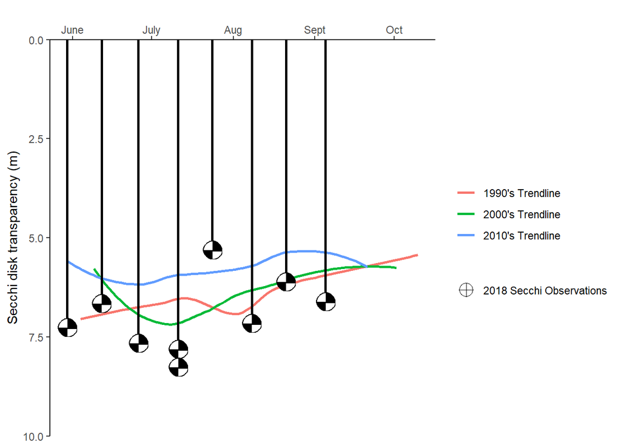

#### In Season Water Temperature

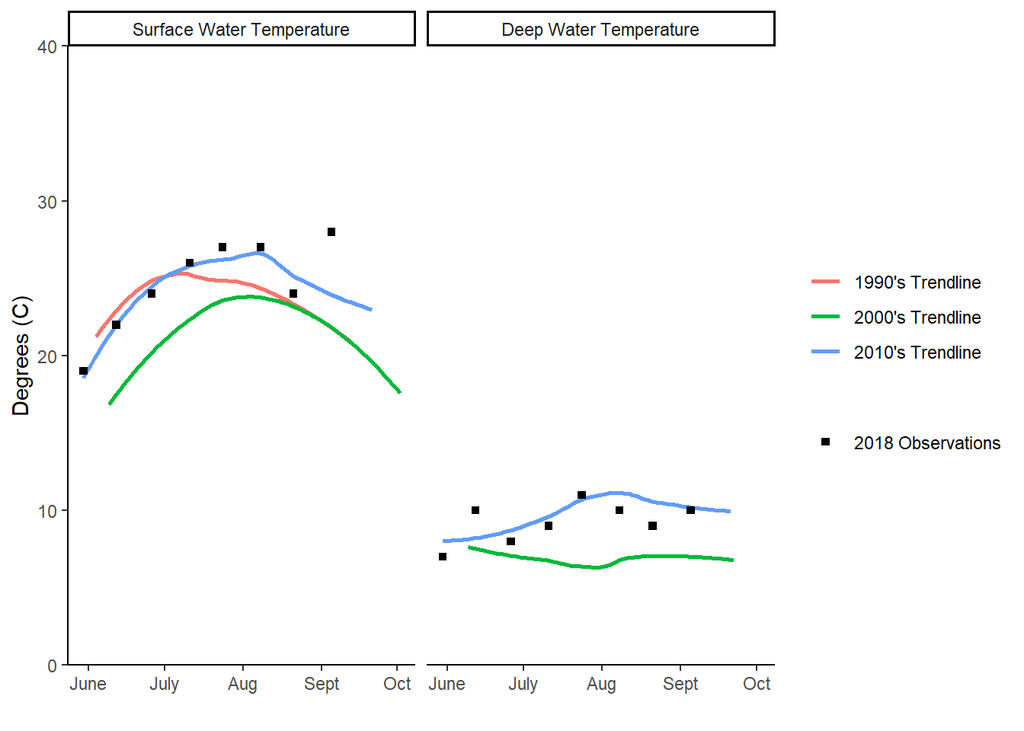